# Project: Investigate a Dataset - TMDb Movies Analysis & Insights

- Introduction
- Dataset Description
- Question for Analysis
- Data Wrangling
- Exploratory Data Analysis
- Conclusions

## Introduction

### Dataset Description

In this report we provide an analysis on *The Movie Database (TMDb)*, which contains information about 10,000 movies, released during the period between 1960-2015 years. The dataset contains information valuable for the decision making in relation to the movie production, such as:

- underlying details of a movie (title, genre, director, cast, production company, tagline, keywords, homepage and overview);
- economics: budget and revenue in nominal and real terms (adjusted for inflation, in 2010 US $);
- popularity, average user rating and count;
- duration and release period.

For more details of a dataset, please refer to the section below.

```python
# Setting up import statements for the required packages used in this report
import pandas as pd
import matplotlib.pyplot as plt
import numpy as np
import seaborn as sns
from datetime import datetime
```

```python
# Loading The Movie Database (TMDb) data
df=pd.read_csv('Database_TMDb_movie_data/tmdb-movies.csv')
```

This dataset contains 21 columns and 10,866 entries of integer, float and object types.

> **NOTE 1**. Release date has *Object* datatype and will be converted to the relevant *Date* Type in Data Wrangling section of the report

```python
df.info()
```

```
<class 'pandas.core.frame.DataFrame'>
RangeIndex: 10866 entries, 0 to 10865
Data columns (total 21 columns):
 #   Column                Non-Null Count  Dtype
---  ------                --------------  -----
 0   id                    10866 non-null  int64
 1   imdb_id               10856 non-null  object
 2   popularity            10866 non-null  float64
 3   budget                10866 non-null  int64
 4   revenue               10866 non-null  int64
 5   original_title        10866 non-null  object
 6   cast                  10790 non-null  object
 7   homepage              2936 non-null   object
 8   director              10822 non-null  object
 9   tagline               8042 non-null   object
 10  keywords              9373 non-null   object
 11  overview              10862 non-null  object
 12  runtime               10866 non-null  int64
 13  genres                10843 non-null  object
 14  production_companies  9836 non-null   object
 15  release_date          10866 non-null  object
 16  vote_count            10866 non-null  int64
 17  vote_average          10866 non-null  float64
 18  release_year          10866 non-null  int64
 19  budget_adj            10866 non-null  float64
 20  revenue_adj           10866 non-null  float64
dtypes: float64(4), int64(6), object(11)
memory usage: 1.7+ MB
```

```python
df.describe()
```

|  | id | popularity | budget | revenue | runtime | vote_count | vote_average | release_year | budget_adj | revenue_adj |
| --- | --- | --- | --- | --- | --- | --- | --- | --- | --- | --- |
| count | 10866.000000 | 10866.000000 | 1.086600e+04 | 1.086600e+04 | 10866.000000 | 10866.000000 | 10866.000000 | 10866.000000 | 1.086600e+04 | 1.086600e+04 |
| mean | 66064.177434 | 0.646441 | 1.462570e+07 | 3.982332e+07 | 102.070863 | 217.389748 | 5.974922 | 2001.322658 | 1.755104e+07 | 5.136436e+07 |
| std | 92130.136561 | 1.000185 | 3.091321e+07 | 1.170035e+08 | 31.381405 | 575.619058 | 0.935142 | 12.812941 | 3.430616e+07 | 1.446325e+08 |
| min | 5.000000 | 0.000065 | 0.000000e+00 | 0.000000e+00 | 0.000000 | 10.000000 | 1.500000 | 1960.000000 | 0.000000e+00 | 0.000000e+00 |
| 25% | 10596.250000 | 0.207583 | 0.000000e+00 | 0.000000e+00 | 90.000000 | 17.000000 | 5.400000 | 1995.000000 | 0.000000e+00 | 0.000000e+00 |
| 50% | 20669.000000 | 0.383856 | 0.000000e+00 | 0.000000e+00 | 99.000000 | 38.000000 | 6.000000 | 2006.000000 | 0.000000e+00 | 0.000000e+00 |
| 75% | 75610.000000 | 0.713817 | 1.500000e+07 | 2.400000e+07 | 111.000000 | 145.750000 | 6.600000 | 2011.000000 | 2.085325e+07 | 3.369710e+07 |
| max | 417859.000000 | 32.985763 | 4.250000e+08 | 2.781506e+09 | 900.000000 | 9767.000000 | 9.200000 | 2015.000000 | 4.250000e+08 | 2.827124e+09 |

Based on the description of numerical columns and histograms presented below, the following observations have been made:

> **OBSERVATION 1**. Popularity column seems to have outliers in dataset, where mean and 25-75 percentiles are in a range of 0-1 and max value goes up to 32.99 points. Below histogram for popularity as well shows skewness to the left of the majority of values, indicating for the existence of outliers, which potentially can be investigated in a separate analysis.

> **OBSERVATION 2**. Budget, revenue and their adjusted versions have a significant portion of zero values. For the purpose of this analysis, we assume that the dataset in this regard is correct and zero values represent unsuccessful releases with no budget, thus avoiding cleaning dataset removing zero line items in this case.

> **OBSERVATION 3**. Runtime has a mean of 102 and median of 99, indicating that there is a certain movie runtime standard in the industry. However, as there are still 247 unique values in the runtime field, for the purpose of our analysis we have decided to use additionally 3 categories of movies based on runtime statistics, grouping as per below:

```
      >> Short   <= 90 min ; Medium  > 90 and <= 111 min ; Long    > 111 min
```

> **OBSERVATION 4**. Following the description of Vote average, we can assume that User rating is between 0-10, where 10 has the maximum value.

> **OBSERVATION 5**. Although database contains information for more than 50 years, the later years has increasing number of movies compared to the earlier periods (that can be seen in the histogram below for Release year). Meaning that our analysis will be impacted by the increased number of movies produced overtime, esp. in the later periods

```python
# Generating a function to plot histograms for the selected columns in the dataset
def generate_histogram(df, column_name, bins=10, title='Histogram', xlabel='Values', ylabel='Frequency'):
    plt.figure(figsize=(10, 6))
    plt.hist(df[column_name], bins=bins, color='blue', alpha=0.7, edgecolor='black')
    plt.title(title)
    plt.xlabel(xlabel)
    plt.ylabel(ylabel)
    plt.grid(axis='y', alpha=0.75)
    plt.show()
```

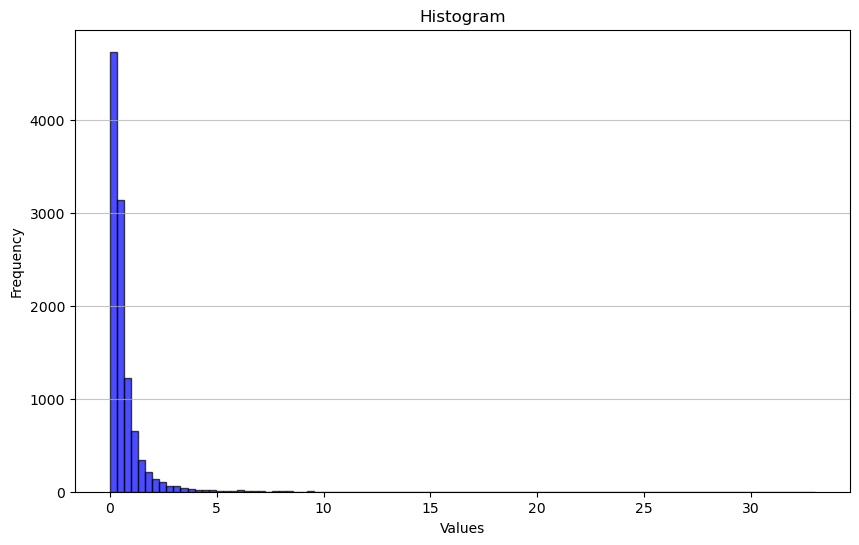

```python
# Plotting a histogram for Popularity
generate_histogram(df, 'popularity', bins=100)
```

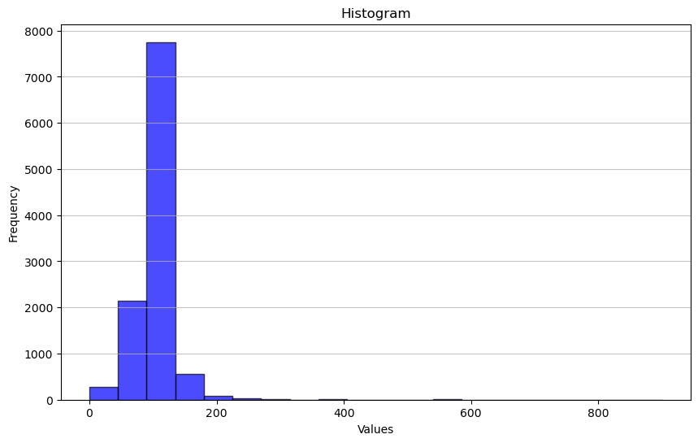

```python
# Plotting a histogram for Runtime
generate_histogram(df, 'runtime', bins=20)
```

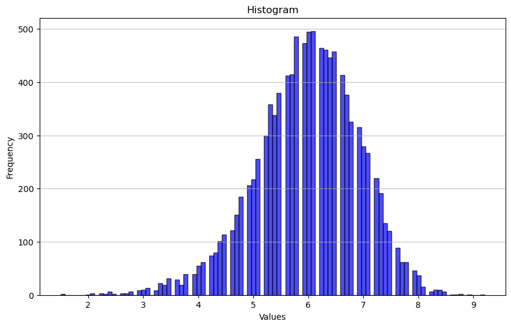

```python
# Plotting a histogram for User rating
generate_histogram(df, 'vote_average', bins=100)
```

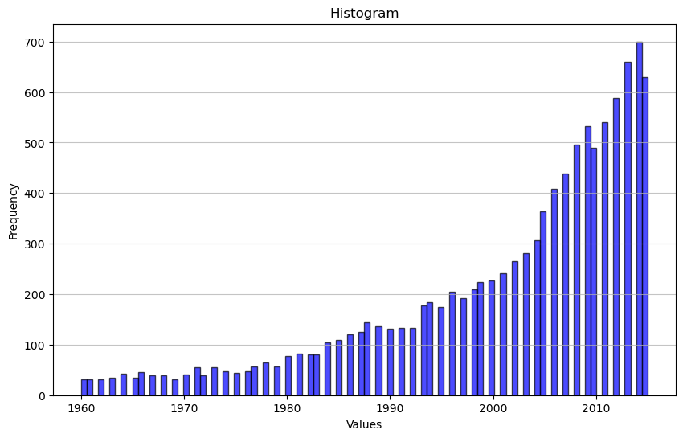

```python
# Plotting a histogram for Release_year
generate_histogram(df, 'release_year', bins=100)
```

```python
# Sample of rows to get a feeling for input data
df.head()
```

|  | id | imdb_id | popularity | budget | revenue | original_title | cast | homepage | director | tagline | ... | overview | runtime | genres | production_companies | release_date | vote_count | vote_average | release_year | budget_adj | revenue_adj |
| --- | --- | --- | --- | --- | --- | --- | --- | --- | --- | --- | --- | --- | --- | --- | --- | --- | --- | --- | --- | --- | --- |
| 0 | 135397 | tt0369610 | 32.985763 | 150000000 | 1513528810 | Jurassic World | Chris Pratt\|Bryce Dallas Howard\|Irrfan Khan\|Vi... | http://www.jurassicworld.com/ | Colin Trevorrow | The park is open. | ... | Twenty-two years after the events of Jurassic ... | 124 | Action\|Adventure\|Science Fiction\|Thriller | Universal Studios\|Amblin Entertainment\|Legenda... | 6/9/15 | 5562 | 6.5 | 2015 | 1.379999e+08 | 1.392446e+09 |
| 1 | 76341 | tt1392190 | 28.419936 | 150000000 | 378436354 | Mad Max: Fury Road | Tom Hardy\|Charlize Theron\|Hugh Keays-Byrne\|Nic... | http://www.madmaxmovie.com/ | George Miller | What a Lovely Day. | ... | An apocalyptic story set in the furthest reach... | 120 | Action\|Adventure\|Science Fiction\|Thriller | Village Roadshow Pictures\|Kennedy Miller Produ... | 5/13/15 | 6185 | 7.1 | 2015 | 1.379999e+08 | 3.481613e+08 |
| 2 | 262500 | tt2908446 | 13.112507 | 110000000 | 295238201 | Insurgent | Shailene Woodley\|Theo James\|Kate Winslet\|Ansel... | http://www.thedivergentseries.movie/#insurgent | Robert Schwentke | One Choice Can Destroy You | ... | Beatrice Prior must confront her inner demons ... | 119 | Adventure\|Science Fiction\|Thriller | Summit Entertainment\|Mandeville Films\|Red Wago... | 3/18/15 | 2480 | 6.3 | 2015 | 1.012000e+08 | 2.716190e+08 |
| 3 | 140607 | tt2488496 | 11.173104 | 200000000 | 2068178225 | Star Wars: The Force Awakens | Harrison Ford\|Mark Hamill\|Carrie Fisher\|Adam D... | http://www.starwars.com/films/star-wars-episod... | J.J. Abrams | Every generation has a story. | ... | Thirty years after defeating the Galactic Empi... | 136 | Action\|Adventure\|Science Fiction\|Fantasy | Lucasfilm\|Truenorth Productions\|Bad Robot | 12/15/15 | 5292 | 7.5 | 2015 | 1.839999e+08 | 1.902723e+09 |
| 4 | 168259 | tt2820852 | 9.335014 | 190000000 | 1506249360 | Furious 7 | Vin Diesel\|Paul Walker\|Jason Statham\|Michelle ... | http://www.furious7.com/ | James Wan | Vengeance Hits Home | ... | Deckard Shaw seeks revenge against Dominic Tor... | 137 | Action\|Crime\|Thriller | Universal Pictures\|Original Film\|Media Rights ... | 4/1/15 | 2947 | 7.3 | 2015 | 1.747999e+08 | 1.385749e+09 |

5 rows × 21 columns

```python
df.tail()
```

|  | id | imdb_id | popularity | budget | revenue | original_title | cast | homepage | director | tagline | ... | overview | runtime | genres | production_companies | release_date | vote_count | vote_average | release_year | budget_adj | revenue_adj |
| --- | --- | --- | --- | --- | --- | --- | --- | --- | --- | --- | --- | --- | --- | --- | --- | --- | --- | --- | --- | --- | --- |
| 10861 | 21 | tt0060371 | 0.080598 | 0 | 0 | The Endless Summer | Michael Hynson\|Robert August\|Lord 'Tally Ho' B... | NaN | Bruce Brown | NaN | ... | The Endless Summer, by Bruce Brown, is one of ... | 95 | Documentary | Bruce Brown Films | 6/15/66 | 11 | 7.4 | 1966 | 0.000000 | 0.0 |
| 10862 | 20379 | tt0060472 | 0.065543 | 0 | 0 | Grand Prix | James Garner\|Eva Marie Saint\|Yves Montand\|Tosh... | NaN | John Frankenheimer | Cinerama sweeps YOU into a drama of speed and ... | ... | Grand Prix driver Pete Aron is fired by his te... | 176 | Action\|Adventure\|Drama | Cherokee Productions\|Joel Productions\|Douglas ... | 12/21/66 | 20 | 5.7 | 1966 | 0.000000 | 0.0 |
| 10863 | 39768 | tt0060161 | 0.065141 | 0 | 0 | Beregis Avtomobilya | Innokentiy Smoktunovskiy\|Oleg Efremov\|Georgi Z... | NaN | Eldar Ryazanov | NaN | ... | An insurance agent who moonlights as a carthie... | 94 | Mystery\|Comedy | Mosfilm | 1/1/66 | 11 | 6.5 | 1966 | 0.000000 | 0.0 |
| 10864 | 21449 | tt0061177 | 0.064317 | 0 | 0 | What's Up, Tiger Lily? | Tatsuya Mihashi\|Akiko Wakabayashi\|Mie Hama\|Joh... | NaN | Woody Allen | WOODY ALLEN STRIKES BACK! | ... | In comic Woody Allen's film debut, he took the... | 80 | Action\|Comedy | Benedict Pictures Corp. | 11/2/66 | 22 | 5.4 | 1966 | 0.000000 | 0.0 |
| 10865 | 22293 | tt0060666 | 0.035919 | 19000 | 0 | Manos: The Hands of Fate | Harold P. Warren\|Tom Neyman\|John Reynolds\|Dian... | NaN | Harold P. Warren | It's Shocking! It's Beyond Your Imagination! | ... | A family gets lost on the road and stumbles up... | 74 | Horror | Norm-Iris | 11/15/66 | 15 | 1.5 | 1966 | 127642.279154 | 0.0 |

5 rows × 21 columns

```python
# An analysis on unique values, where runtime has 247 unique values as indicated above
df.nunique()
```

```
id                      10865
imdb_id                 10855
popularity              10814
budget                    557
revenue                  4702
original_title          10571
cast                    10719
homepage                 2896
director                 5067
tagline                  7997
keywords                 8804
overview                10847
runtime                   247
genres                   2039
production_companies     7445
release_date             5909
vote_count               1289
vote_average               72
release_year               56
budget_adj               2614
revenue_adj              4840
dtype: int64
```

```python
# Analysis on the existence of null values
df.isnull().sum()
```

```
id                         0
imdb_id                   10
popularity                 0
budget                     0
revenue                    0
original_title             0
cast                      76
homepage                7930
director                  44
tagline                 2824
keywords                1493
overview                   4
runtime                    0
genres                    23
production_companies    1030
release_date               0
vote_count                 0
vote_average               0
release_year               0
budget_adj                 0
revenue_adj                0
dtype: int64
```

As per above information on null values, the dataset is generally clean for null values, especially in regards to the numerical columns, which we will use for our further analysis.

> **OBSERVATION 6** There are 10 missing values for imdb_id column, which are listed and presented below. However as they contain relevant information and we generally do not use imbd_id column, further data cleaning steps on that column was assumed to be irrelevant .

```python
# Show rows where 'imdb_id' is null
df[df['imdb_id'].isnull()]
```

|  | id | imdb_id | popularity | budget | revenue | original_title | cast | homepage | director | tagline | ... | overview | runtime | genres | production_companies | release_date | vote_count | vote_average | release_year | budget_adj | revenue_adj |
| --- | --- | --- | --- | --- | --- | --- | --- | --- | --- | --- | --- | --- | --- | --- | --- | --- | --- | --- | --- | --- | --- |
| 548 | 355131 | NaN | 0.108072 | 0 | 0 | Sense8: Creating the World | Tuppence Middleton\|Bae Doona \|Brian J. Smith\|A... | NaN | NaN | NaN | ... | NaN | 25 | Documentary\|Science Fiction | Netflix | 8/10/15 | 12 | 7.5 | 2015 | 0.000000 | 0.0 |
| 997 | 287663 | NaN | 0.330431 | 0 | 0 | Star Wars Rebels: Spark of Rebellion | Freddie Prinze Jr.\|Vanessa Marshall\|Steve Blum... | NaN | Steward Lee\|Steven G. Lee | NaN | ... | A Long Time Ago In A Galaxy Far, Far Away… A... | 44 | NaN | NaN | 10/3/14 | 13 | 6.8 | 2014 | 0.000000 | 0.0 |
| 1528 | 15257 | NaN | 0.607851 | 0 | 0 | Hulk vs. Wolverine | Fred Tatasciore\|Bryce Johnson\|Steve Blum\|Nolan... | NaN | Frank Paur | NaN | ... | Department H sends in Wolverine to track down ... | 38 | Animation\|Action\|Science Fiction | Marvel Studios | 1/27/09 | 38 | 6.9 | 2009 | 0.000000 | 0.0 |
| 1750 | 101907 | NaN | 0.256975 | 0 | 0 | Hulk vs. Thor | Graham McTavish\|Fred Tatasciore\|Matthew Wolf\|J... | NaN | Sam Liu | A Battle Between God and Monster | ... | For ages, Odin has protected his kingdom of As... | 41 | Action\|Animation\|Fantasy\|Science Fiction | Marvel Studios | 1/27/09 | 38 | 6.4 | 2009 | 0.000000 | 0.0 |
| 2401 | 45644 | NaN | 0.067753 | 0 | 0 | Opeth: In Live Concert At The Royal Albert Hall | Mikael Åkerfeldt\|Martin "Axe" Axenrot\|Martin ... | http://www.opeth.com | NaN | The Loyal Disharmonic Orchestra, Conducted By ... | ... | As part of the ongoing celebration of their 20... | 163 | Music | NaN | 9/21/10 | 10 | 8.6 | 2010 | 0.000000 | 0.0 |
| 4797 | 369145 | NaN | 0.167501 | 0 | 0 | Doctor Who: The Snowmen | Matt Smith\|Jenna Coleman\|Richard E. Grant\|Ian ... | NaN | NaN | NaN | ... | Christmas Eve, 1892, and the falling snow is t... | 60 | NaN | BBC Television UK | 12/25/12 | 10 | 7.8 | 2012 | 0.000000 | 0.0 |
| 4872 | 269177 | NaN | 0.090552 | 0 | 0 | Party Bercy | Florence Foresti | NaN | NaN | NaN | ... | Florence Foresti is offered Bercy tribute to a... | 120 | Comedy | TF1 Vidéo | 9/23/12 | 15 | 6.4 | 2012 | 0.000000 | 0.0 |
| 6071 | 279954 | NaN | 0.004323 | 500 | 0 | Portal: Survive! | Monique Blanchard\|Bradley Mixon | https://www.kickstarter.com/projects/colinandc... | Connor McGuire\|Colin McGuire | The Cake is a Lie | ... | A short, live action fan film by Collin and Co... | 7 | Action\|Science Fiction | NaN | 10/8/13 | 11 | 7.5 | 2013 | 468.016676 | 0.0 |
| 7527 | 50127 | NaN | 0.570337 | 0 | 0 | Fallen: The Journey | Paul Wesley\|Fernanda Andrade\|Tom Skerritt\|Rick... | NaN | Mikael Salomon | NaN | ... | A year later, Aaron is still traveling around ... | 80 | Action\|Adventure\|Drama\|Fantasy\|Family | NaN | 1/1/07 | 11 | 7.3 | 2007 | 0.000000 | 0.0 |
| 7809 | 50128 | NaN | 0.060795 | 0 | 0 | Fallen: The Destiny | Paul Wesley\|Fernanda Andrade\|Tom Skerritt\|Rick... | NaN | Mikael Salomon | NaN | ... | Aaron and Azazel defeat the Powers, and force ... | 80 | Adventure\|Fantasy\|Drama\|Action\|Science Fiction | NaN | 1/1/07 | 13 | 7.0 | 2007 | 0.000000 | 0.0 |

10 rows × 21 columns

> Listing the lines with popularity > 2 for the potential further analysis on **outliers and their treatment**, which is out of scope of the current report

```python
df[df['popularity'] > 2]
```

|  | id | imdb_id | popularity | budget | revenue | original_title | cast | homepage | director | tagline | ... | overview | runtime | genres | production_companies | release_date | vote_count | vote_average | release_year | budget_adj | revenue_adj |
| --- | --- | --- | --- | --- | --- | --- | --- | --- | --- | --- | --- | --- | --- | --- | --- | --- | --- | --- | --- | --- | --- |
| 0 | 135397 | tt0369610 | 32.985763 | 150000000 | 1513528810 | Jurassic World | Chris Pratt\|Bryce Dallas Howard\|Irrfan Khan\|Vi... | http://www.jurassicworld.com/ | Colin Trevorrow | The park is open. | ... | Twenty-two years after the events of Jurassic ... | 124 | Action\|Adventure\|Science Fiction\|Thriller | Universal Studios\|Amblin Entertainment\|Legenda... | 6/9/15 | 5562 | 6.5 | 2015 | 1.379999e+08 | 1.392446e+09 |
| 1 | 76341 | tt1392190 | 28.419936 | 150000000 | 378436354 | Mad Max: Fury Road | Tom Hardy\|Charlize Theron\|Hugh Keays-Byrne\|Nic... | http://www.madmaxmovie.com/ | George Miller | What a Lovely Day. | ... | An apocalyptic story set in the furthest reach... | 120 | Action\|Adventure\|Science Fiction\|Thriller | Village Roadshow Pictures\|Kennedy Miller Produ... | 5/13/15 | 6185 | 7.1 | 2015 | 1.379999e+08 | 3.481613e+08 |
| 2 | 262500 | tt2908446 | 13.112507 | 110000000 | 295238201 | Insurgent | Shailene Woodley\|Theo James\|Kate Winslet\|Ansel... | http://www.thedivergentseries.movie/#insurgent | Robert Schwentke | One Choice Can Destroy You | ... | Beatrice Prior must confront her inner demons ... | 119 | Adventure\|Science Fiction\|Thriller | Summit Entertainment\|Mandeville Films\|Red Wago... | 3/18/15 | 2480 | 6.3 | 2015 | 1.012000e+08 | 2.716190e+08 |
| 3 | 140607 | tt2488496 | 11.173104 | 200000000 | 2068178225 | Star Wars: The Force Awakens | Harrison Ford\|Mark Hamill\|Carrie Fisher\|Adam D... | http://www.starwars.com/films/star-wars-episod... | J.J. Abrams | Every generation has a story. | ... | Thirty years after defeating the Galactic Empi... | 136 | Action\|Adventure\|Science Fiction\|Fantasy | Lucasfilm\|Truenorth Productions\|Bad Robot | 12/15/15 | 5292 | 7.5 | 2015 | 1.839999e+08 | 1.902723e+09 |
| 4 | 168259 | tt2820852 | 9.335014 | 190000000 | 1506249360 | Furious 7 | Vin Diesel\|Paul Walker\|Jason Statham\|Michelle ... | http://www.furious7.com/ | James Wan | Vengeance Hits Home | ... | Deckard Shaw seeks revenge against Dominic Tor... | 137 | Action\|Crime\|Thriller | Universal Pictures\|Original Film\|Media Rights ... | 4/1/15 | 2947 | 7.3 | 2015 | 1.747999e+08 | 1.385749e+09 |
| ... | ... | ... | ... | ... | ... | ... | ... | ... | ... | ... | ... | ... | ... | ... | ... | ... | ... | ... | ... | ... | ... |
| 10438 | 657 | tt0057076 | 2.508235 | 2500000 | 78898765 | From Russia With Love | Sean Connery\|Daniela Bianchi\|Lotte Lenya\|Rober... | http://www.mgm.com/view/movie/717/From-Russia-... | Terence Young | The world's masters of murder pull out all the... | ... | Agent 007 is back in the second installment of... | 115 | Action\|Thriller\|Adventure | Eon Productions\|Metro-Goldwyn-Mayer (MGM)\|Danjaq | 10/11/63 | 458 | 6.7 | 1963 | 1.780045e+07 | 5.617734e+08 |
| 10439 | 9078 | tt0057546 | 2.180410 | 0 | 0 | The Sword in the Stone | Sebastian Cabot\|Karl Swenson\|Junius Matthews\|N... | NaN | Wolfgang Reitherman | Tired of living in a Medieval mess...Merlin us... | ... | Wart is a young boy who aspires to be a knight... | 79 | Animation\|Family | Walt Disney Productions | 12/25/63 | 486 | 6.7 | 1963 | 0.000000e+00 | 0.000000e+00 |
| 10472 | 679 | tt0090605 | 2.485419 | 18500000 | 131060248 | Aliens | Sigourney Weaver\|Carrie Henn\|Michael Biehn\|Lan... | NaN | James Cameron | This Time It's War | ... | When Ripley's lifepod is found by a salvage cr... | 137 | Horror\|Action\|Thriller\|Science Fiction | Twentieth Century Fox Film Corporation\|SLM Pro... | 7/18/86 | 2027 | 7.6 | 1986 | 3.680402e+07 | 2.607321e+08 |
| 10593 | 11886 | tt0070608 | 2.272486 | 15000000 | 32056467 | Robin Hood | Brian Bedford\|Phil Harris\|Peter Ustinov\|Pat Bu... | NaN | Wolfgang Reitherman | Meet Robin Hood and his MERRY MENagerie! | ... | With King Richard off to the Crusades, Prince ... | 83 | Animation\|Family | Walt Disney Productions | 11/8/73 | 641 | 6.9 | 1973 | 7.366739e+07 | 1.574344e+08 |
| 10594 | 9552 | tt0070047 | 2.010733 | 8000000 | 441306145 | The Exorcist | Linda Blair\|Max von Sydow\|Ellen Burstyn\|Jason ... | http://theexorcist.warnerbros.com/ | William Friedkin | Something almost beyond comprehension is happe... | ... | 12-year-old Regan MacNeil begins to adapt an e... | 122 | Drama\|Horror\|Thriller | Warner Bros.\|Hoya Productions | 12/26/73 | 1113 | 7.2 | 1973 | 3.928928e+07 | 2.167325e+09 |

567 rows × 21 columns

### Questions for Analysis

Our analysis and hence the report will be focused on the financial and economical aspects of a movie production, specifically what correlates with high revenues (budget, popularity, user rating and/or runtime) and what are the characteristics of a high ROI (Return on Investment) movie.

**Question #1**. What correlates with revenues the most: budgets, popularity, user rating or runtime?

**Question #2**. What are the characteristics of a high ROI movie (from the financial point of view)?

> *where ROI (Return on Investment) is Revenue / Budget (both adjusted for inflation)*

```
Specifically:
```

> - which genres have high ROI;
> - what is the best runtime (range) of movies with the highest ROI;
> - which release months of a year have the highest ROI;
> - whether ROI changed overtime or it's rather stable in relation to a release year.

We have decided to analyse ROI (compared to Revenue only), as high revenues not always ensure a financial success of a movie.

## Data Wrangling

### Data Cleaning

**I. Release date column conversion to a correct Date Type format**, required for further processing of a release date and months during EDA steps below.

Following **NOTE 1** in *Dataset Description* section above, we have converted data type of a Release date to a *Date* format from *Object*.

We will perform this conversion in two steps:

1. convert to a correct data type;
2. use Release year column to extract a year and append it to date and month from the Release date column - This is needed to ensure correct interpretation of a year column, e.g. 1972 vs 2072 for 72 as an example.

```python
# Step 1. Correcting data type
df['release_date'] = pd.to_datetime(df['release_date'], format='%m/%d/%y')

# Step 2. Appending Release date to Release year to ensure correct intepretation of a year column
df['release_date'] = pd.to_datetime(
    df['release_date'].dt.strftime('%m-%d') + '-' + df['release_year'].astype(str),
    format='%m-%d-%Y'
)
df.info()
```

```
<class 'pandas.core.frame.DataFrame'>
RangeIndex: 10866 entries, 0 to 10865
Data columns (total 21 columns):
 #   Column                Non-Null Count  Dtype
---  ------                --------------  -----
 0   id                    10866 non-null  int64
 1   imdb_id               10856 non-null  object
 2   popularity            10866 non-null  float64
 3   budget                10866 non-null  int64
 4   revenue               10866 non-null  int64
 5   original_title        10866 non-null  object
 6   cast                  10790 non-null  object
 7   homepage              2936 non-null   object
 8   director              10822 non-null  object
 9   tagline               8042 non-null   object
 10  keywords              9373 non-null   object
 11  overview              10862 non-null  object
 12  runtime               10866 non-null  int64
 13  genres                10843 non-null  object
 14  production_companies  9836 non-null   object
 15  release_date          10866 non-null  datetime64[ns]
 16  vote_count            10866 non-null  int64
 17  vote_average          10866 non-null  float64
 18  release_year          10866 non-null  int64
 19  budget_adj            10866 non-null  float64
 20  revenue_adj           10866 non-null  float64
dtypes: datetime64[ns](1), float64(4), int64(6), object(10)
memory usage: 1.7+ MB
```

**II. Cleaning for duplicate rows**

Check for duplicate rows, ignoring id column (in case, if there are duplicated rows, but with a new id).

**Result**. 2 duplicate rows: with duplicated id column as well

```python
df[df.duplicated(subset=df.columns.difference(['id']), keep=False)]
```

|  | id | imdb_id | popularity | budget | revenue | original_title | cast | homepage | director | tagline | ... | overview | runtime | genres | production_companies | release_date | vote_count | vote_average | release_year | budget_adj | revenue_adj |
| --- | --- | --- | --- | --- | --- | --- | --- | --- | --- | --- | --- | --- | --- | --- | --- | --- | --- | --- | --- | --- | --- |
| 2089 | 42194 | tt0411951 | 0.59643 | 30000000 | 967000 | TEKKEN | Jon Foo\|Kelly Overton\|Cary-Hiroyuki Tagawa\|Ian... | NaN | Dwight H. Little | Survival is no game | ... | In the year of 2039, after World Wars destroy ... | 92 | Crime\|Drama\|Action\|Thriller\|Science Fiction | Namco\|Light Song Films | 2010-03-20 | 110 | 5.0 | 2010 | 30000000.0 | 967000.0 |
| 2090 | 42194 | tt0411951 | 0.59643 | 30000000 | 967000 | TEKKEN | Jon Foo\|Kelly Overton\|Cary-Hiroyuki Tagawa\|Ian... | NaN | Dwight H. Little | Survival is no game | ... | In the year of 2039, after World Wars destroy ... | 92 | Crime\|Drama\|Action\|Thriller\|Science Fiction | Namco\|Light Song Films | 2010-03-20 | 110 | 5.0 | 2010 | 30000000.0 | 967000.0 |

2 rows × 21 columns

Removing dulicated rows:

```python
df=df.drop_duplicates()
```

**III. Transforming Genres data**. During EDA process we are planning to use Genres for our analysis, specifically in calculation of ROI per genre. However, data on Genres is stored in one column and this column contains several values, separated by "|", which needs to be transformed. Please follow below commented steps to get insights into the logic of the transformation.

**Result**. 20 unique Genres, each in a separate column with binary values (0 - no, 1 -yes)

**LIMITATION**. Each movie can be in several genres, which means that the total count of all the genres will be higher than the total number of movies. Subsequently, there is duplicated statistics in those cases.

```python
# Transforming the 'genres' column into separate binary columns
genre_dummies = df['genres'].str.get_dummies(sep='|')

# Adding prefix 'Genre_' to each of the new genre columns to easier separate them from the rest of the columns
genre_dummies = genre_dummies.add_prefix('Genre_')

# Concatenate the original DataFrame with the new genre columns
df = pd.concat([df, genre_dummies], axis=1)

# Checking the output
df.info()
df.head()
```

```
<class 'pandas.core.frame.DataFrame'>
Index: 10865 entries, 0 to 10865
Data columns (total 41 columns):
 #   Column                 Non-Null Count  Dtype
---  ------                 --------------  -----
 0   id                     10865 non-null  int64
 1   imdb_id                10855 non-null  object
 2   popularity             10865 non-null  float64
 3   budget                 10865 non-null  int64
 4   revenue                10865 non-null  int64
 5   original_title         10865 non-null  object
 6   cast                   10789 non-null  object
 7   homepage               2936 non-null   object
 8   director               10821 non-null  object
 9   tagline                8041 non-null   object
```

[output cut: 33 more lines]

|  | id | imdb_id | popularity | budget | revenue | original_title | cast | homepage | director | tagline | ... | Genre_History | Genre_Horror | Genre_Music | Genre_Mystery | Genre_Romance | Genre_Science Fiction | Genre_TV Movie | Genre_Thriller | Genre_War | Genre_Western |
| --- | --- | --- | --- | --- | --- | --- | --- | --- | --- | --- | --- | --- | --- | --- | --- | --- | --- | --- | --- | --- | --- |
| 0 | 135397 | tt0369610 | 32.985763 | 150000000 | 1513528810 | Jurassic World | Chris Pratt\|Bryce Dallas Howard\|Irrfan Khan\|Vi... | http://www.jurassicworld.com/ | Colin Trevorrow | The park is open. | ... | 0 | 0 | 0 | 0 | 0 | 1 | 0 | 1 | 0 | 0 |
| 1 | 76341 | tt1392190 | 28.419936 | 150000000 | 378436354 | Mad Max: Fury Road | Tom Hardy\|Charlize Theron\|Hugh Keays-Byrne\|Nic... | http://www.madmaxmovie.com/ | George Miller | What a Lovely Day. | ... | 0 | 0 | 0 | 0 | 0 | 1 | 0 | 1 | 0 | 0 |
| 2 | 262500 | tt2908446 | 13.112507 | 110000000 | 295238201 | Insurgent | Shailene Woodley\|Theo James\|Kate Winslet\|Ansel... | http://www.thedivergentseries.movie/#insurgent | Robert Schwentke | One Choice Can Destroy You | ... | 0 | 0 | 0 | 0 | 0 | 1 | 0 | 1 | 0 | 0 |
| 3 | 140607 | tt2488496 | 11.173104 | 200000000 | 2068178225 | Star Wars: The Force Awakens | Harrison Ford\|Mark Hamill\|Carrie Fisher\|Adam D... | http://www.starwars.com/films/star-wars-episod... | J.J. Abrams | Every generation has a story. | ... | 0 | 0 | 0 | 0 | 0 | 1 | 0 | 0 | 0 | 0 |
| 4 | 168259 | tt2820852 | 9.335014 | 190000000 | 1506249360 | Furious 7 | Vin Diesel\|Paul Walker\|Jason Statham\|Michelle ... | http://www.furious7.com/ | James Wan | Vengeance Hits Home | ... | 0 | 0 | 0 | 0 | 0 | 0 | 0 | 1 | 0 | 0 |

5 rows × 41 columns

Additional notes:

- Following **OBSERVATION 1** above we do not clean for potential outliers in popularity column.
- Following **OBSERVATION 2** above we accept zero values for revenue and budget as correct.
- Following **OBSERVATION 6** above we keep 10 missing values for imdb_id column.

## Exploratory Data Analysis

### Research Question 1. What correlates with movie revenues the most: budget, popularity, user rating or runtime?

> **Note 2**. Revenue and budgets are adjusted for inflation (in 2010 of US$)

I. First, we vizualize the relationship between Revenue and Budget using a Scatter plot.

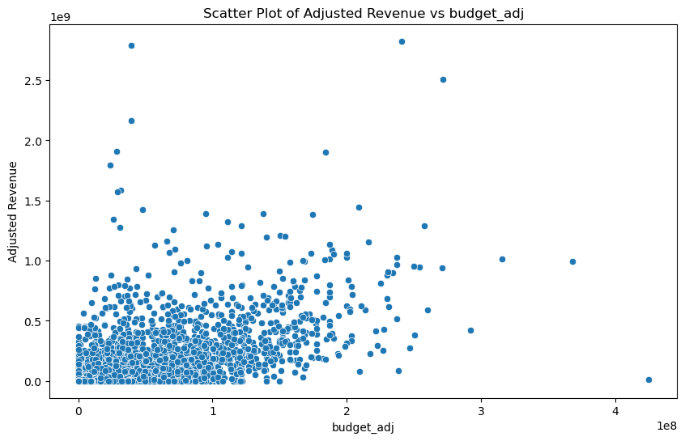

```python
def plot_scatter(df, x_column):
    plt.figure(figsize=(10, 6))
    sns.scatterplot(data=df, x=x_column, y='revenue_adj')
    plt.xlabel(x_column)
    plt.title(f'Scatter Plot of Adjusted Revenue vs {x_column}')
    plt.ylabel(ylabel='Adjusted Revenue')
    plt.show()

plot_scatter(df, 'budget_adj')
```

II. After an initial screening, let's look into the relationship between Revenue and Budget, but bringing Release year information into the picture. To avoid generating >50 graphs for each year, we have grouped them into 5 categories as per below. Additionally, we have added a regression line to better observe the correlation.

```python
# Define a function to categorize years into custom ranges
def categorize_year(year):
    if year < 1975:
        return '1960-1974'
    elif year < 1990:
        return '1975-1989'
    elif year < 2000:
        return '1990-1999'
    elif year < 2010:
        return '2000-2009'
    else:
        return '2010-2015'

# Apply the function to create a new column 'year_range'
df['year_range'] = df['release_year'].apply(categorize_year)

# Sort the DataFrame by year ranges from latest to oldest
year_order = ['2010-2015', '2000-2009', '1990-1999', '1975-1989', '1960-1974']
df['year_range'] = pd.Categorical(df['year_range'], categories=year_order, ordered=True)
df = df.sort_values('year_range')

def plot_scatter_by_variable(df, variable):
    # Creating scatter plots for each year range
    year_ranges = df['year_range'].unique()

    # Create a figure with subplots for each year range, using a grid layout
    ncols = 2  # Number of columns
    nrows = (len(year_ranges) + ncols - 1) // ncols  # Calculate number of rows needed
    fig, axes = plt.subplots(nrows=nrows, ncols=ncols, figsize=(12, 5 * nrows))
    # Flatten axes array if necessary
    axes = axes.flatten()

    # Create a scatter plot
    for ax, year_range in zip(axes, year_ranges):
        # Filter the DataFrame for the current year range
        range_data = df[df['year_range'] == year_range]

        # Create the scatter plot for the current year range
        ax.scatter(range_data[variable], range_data['revenue_adj'], alpha=0.5, label='Data Points')

        # Fit a linear regression line
        if len(range_data) > 1:  # Ensure there are enough points to fit a line
            # Calculate the linear regression line
            slope, intercept = np.polyfit(range_data[variable], range_data['revenue_adj'], 1)
            x_vals = np.array(range_data[variable])
            y_vals = slope * x_vals + intercept
            ax.plot(x_vals, y_vals, color='red', label='Regression Line')

        # Adding labels and title for each subplot
        ax.set_title(f'Scatter Plot of Adj Revenue vs {variable.capitalize()} for {year_range}', fontsize=12)
        ax.set_xlabel(variable.capitalize(), fontsize=10)
        ax.set_ylabel('Adjusted Revenue', fontsize=10)
        ax.grid()
        ax.legend()

    # Hide any unused subplots
    for i in range(len(year_ranges), len(axes)):
        fig.delaxes(axes[i])
    plt.tight_layout()

    # Show the plot
    plt.show()
```

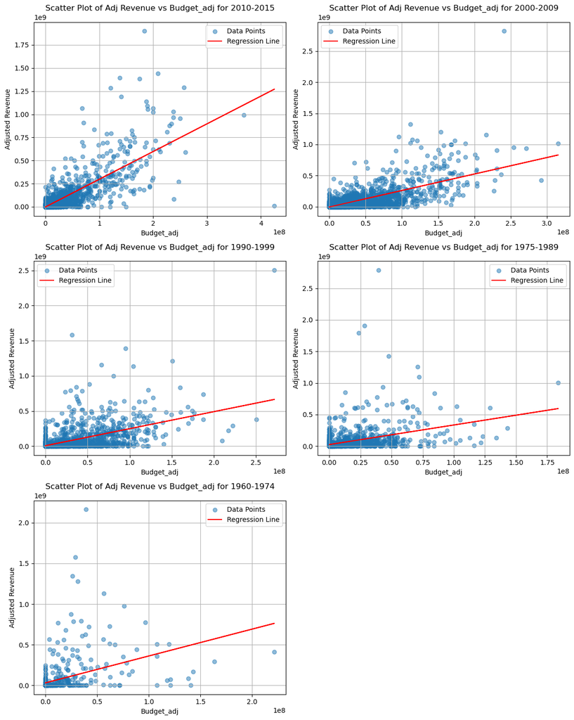

```python
plot_scatter_by_variable(df, 'budget_adj')
```

> **Insight 1.** Following the regression line we can see that there is a relationship of Revenue and Budget. This relationship is becoming more apparent in the latest years, especially in 2010-2015. We can come to the conclusion at this stage that investing more money during the movie production can eventually result in higher revenues, especially in the recent years.

III. In order to quantify the relationship between Revenue and Budget, let's calculate the correlation coefficient using the same year categories

```python
def calculate_correlation(df, variable):
    # Group by 'year_range' and calculate the correlation coefficient
    correlation_results = df.groupby('year_range', observed=True).agg(
        correlation_coefficient=('revenue_adj', lambda x: x.corr(df.loc[x.index, variable]))
    )

    # Convert results to a DataFrame for better readability
    correlation_df = correlation_results.reset_index()

    return correlation_df
```

```python
correlation_budget = calculate_correlation(df, 'budget_adj')
print(correlation_budget)
```

```
  year_range  correlation_coefficient
0  2010-2015                 0.798283
1  2000-2009                 0.736091
2  1990-1999                 0.564771
3  1975-1989                 0.402568
4  1960-1974                 0.409451
```

> **Insight 2.** Correlation coefficients (especially in the last two decades) show a strong positive correlation as well. This suggests that higher budgets were associated with significantly higher revenues and there is a trend of an increased importance of budget in the recent years.

Now let's perform a similar analysis, but for popularity, using defined previously function

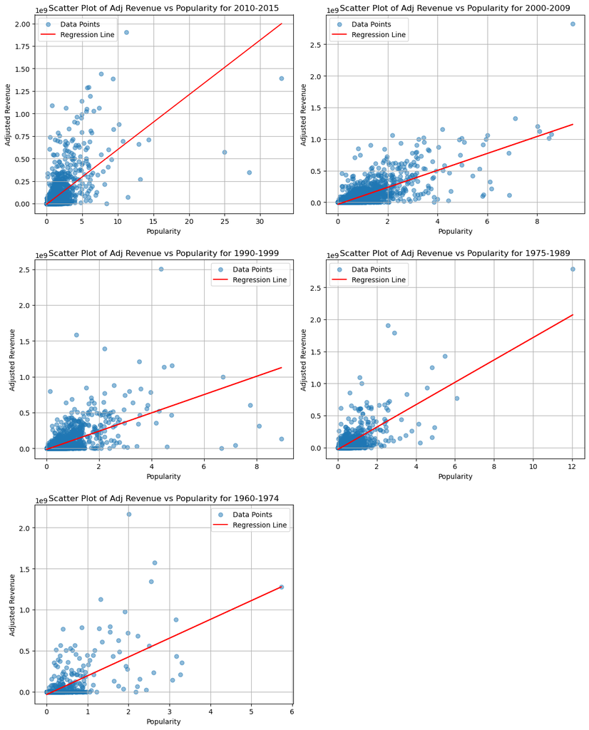

```python
plot_scatter_by_variable(df, 'popularity')
```

Calculating correlation for popularity per year category, where there seem to be no apparent trend throughout year categories.

```python
correlation_popularity = calculate_correlation(df, 'popularity')
print(correlation_popularity)
```

```
  year_range  correlation_coefficient
0  2010-2015                 0.657682
1  2000-2009                 0.757928
2  1990-1999                 0.598830
3  1975-1989                 0.706640
4  1960-1974                 0.621274
```

Now let's look into the correlation of popularity and revenue, but without splitting into the year categories.

```python
def calculate_correlation_single(df, variable1, variable2):
    correlation_coefficient = df[variable1].corr(df[variable2])
    return correlation_coefficient

print(calculate_correlation_single(df, 'revenue_adj', 'popularity'))
```

```
0.6090853022548016
```

> **Insight #3**. Popularity correlates with Revenue, but the trend doesn't seem to be highly dependant from a Release year categories, as in the case with the budget.

```python
# For Budget w/o considering categories of years
print(calculate_correlation_single(df, 'revenue_adj', 'budget_adj'))
```

```
0.6466266122347978
```

Now let's calculate correlation for other variables in question:

```python
# For User rating or Vote average
print(calculate_correlation_single(df, 'revenue_adj', 'vote_average'))
```

```
0.19306239300279376
```

```python
# For runtime
print(calculate_correlation_single(df, 'revenue_adj', 'runtime'))
```

```
0.17566772200926473
```

> **Insight #4**. Budget correlates with Revenue the most, adjusted for inflation. This correlation is stronger than Popularity, Vote average and Runtime. Popularity has a positive correlation as well, while Runtime and Vote average seem to follow a different pattern looking into the scatter plots below.

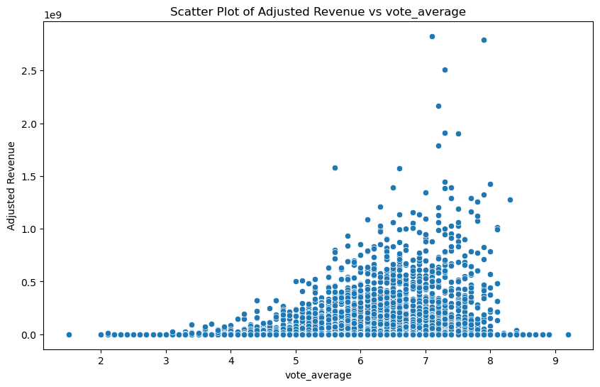

```python
plot_scatter(df, 'vote_average')
```

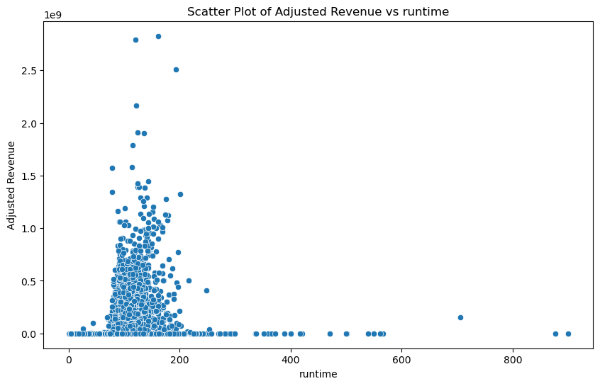

```python
plot_scatter(df, 'runtime')
```

Let's look closely into the Vote average and Runtime statistics

```python
df[['vote_average','runtime']].describe()
```

|  | vote_average | runtime |
| --- | --- | --- |
| count | 10865.000000 | 10865.000000 |
| mean | 5.975012 | 102.071790 |
| std | 0.935138 | 31.382701 |
| min | 1.500000 | 0.000000 |
| 25% | 5.400000 | 90.000000 |
| 50% | 6.000000 | 99.000000 |
| 75% | 6.600000 | 111.000000 |
| max | 9.200000 | 900.000000 |

> **Insight #5**. All movies in general (without significant correlation to Revenue) have average of 102 min of a Runtime and ~6 user rating. Higher Revenue movies generally visually seems to have above average rating, but not per se close to 10 as it would be expected.

### Research Question 2 What are the characteristics of a high ROI movie (from the financial point of view)?

> *where ROI (Return on Investment) = Revenue / Budget (both adjusted for inflation)*

```
Specifically:
```

> - which genres have high ROI;
> - what is the best runtime (range) of movies with the highest ROI;
> - which release months of a year have high ROI;
> - whether ROI changed overtime or it's rather stable in relation to a release year.

In order to calculate ROI, in the below analysis we used two different approaches:

1. via calculating **Total ROI** per genre, e.g. summing Total Revenue generated for all the movies in scope divided by (/) the Total Budget Spend for all the movies in scope. If we assume that the movies in scope represent a movie production industry, then we calculate what will be ROI of a movie production industry as a whole, without considering ROI per movie.
2. **ROI per movie**

Resulting Total ROI (I) and ROI per movie (II) calculations give a different perspective on the analysis from the financial point of view.

I. In the below calculations we derive Total ROI for the movies in scope, per genre, without considering ROI per movie to get an overview of Revenue / Budget ratio for the aggregated amounts.

```python
# Creating a DataFrame to hold the ROI per genre
genre_columns = [col for col in df.columns if col.startswith('Genre_')]
roi_per_genre = {}

# Calculate ROI, average revenue, and average budget per genre
for genre in genre_columns:
    # Filter the DataFrame for the current genre
    genre_data = df[df[genre] == 1]

    # Calculate sums for revenue and budget for the genre
    total_revenue = genre_data['revenue_adj'].sum()
    total_budget = genre_data['budget_adj'].sum()

    # Calculate averages for revenue and budget (we decided to show in mln of USD for a better readability)
    average_revenue_mln = genre_data['revenue_adj'].mean() / 1000000
    average_budget_mln = genre_data['budget_adj'].mean() / 1000000

    # Calculate ROI, handling division by zero
    roi = total_revenue / total_budget if total_budget > 0 else 0

    # Count the number of films in the genre
    genre_count = genre_data.shape[0]

    # Store the results in a dictionary
    roi_per_genre[genre] = {
        'Total ROI': roi,
        'AVG Revenue, mln $': average_revenue_mln,
        'AVG Budget, mln $': average_budget_mln,
        'Genre Count': genre_count
    }

# Convert the results to a DataFrame for better readability
roi_per_genre_df = pd.DataFrame.from_dict(roi_per_genre, orient='index').reset_index()
roi_per_genre_df.columns = ['Genre', 'Total ROI', 'AVG Revenue mln$', 'AVG Budget mln$', 'Count']

# Sort the DataFrame by Total ROI in descending order
roi_per_genre_df = roi_per_genre_df.sort_values(by='Total ROI', ascending=False)

# Display the sorted total ROI per genre with averages and genre count
print(roi_per_genre_df)
```

```
                    Genre  Total ROI  AVG Revenue mln$  AVG Budget mln$  Count
5       Genre_Documentary   3.623441          2.258210         0.623223    520
12            Genre_Music   3.591994         46.655920        12.988864    408
2         Genre_Animation   3.370427         85.256127        25.295350    699
7            Genre_Family   3.258694         87.736710        26.923890   1231
1         Genre_Adventure   3.224484        141.675228        43.937335   1471
11           Genre_Horror   3.101507         24.082711         7.764841   1637
14          Genre_Romance   3.078072         48.200221        15.659224   1712
3            Genre_Comedy   3.008546         47.897001        15.920314   3793
8           Genre_Fantasy   2.971846        111.234151        37.429315    916
15  Genre_Science Fiction   2.945995         86.978418        29.524288   1229
0            Genre_Action   2.783919         91.758272        32.960109   2384
6             Genre_Drama   2.721045         40.417138        14.853534   4760
17         Genre_Thriller   2.673026         55.286099        20.682962   2907
4             Genre_Crime   2.630152         56.636410        21.533513   1354
13          Genre_Mystery   2.612078         50.889296        19.482307    810
18              Genre_War   2.419148         69.986113        28.930067    270
19          Genre_Western   1.881881         46.101264        24.497439    165
10          Genre_History   1.805427         47.948584        26.558025    334
16         Genre_TV Movie   1.181115          0.349635         0.296022    167
9           Genre_Foreign   0.749968          1.784286         2.379151    188
```

> **Insight #5**. Counting a full Budget Spend vs Revenue Generated for all the movies in scope as a total, **Documentary** genre has the highest Total ROI, mainly driven by one of the lowest Budget spends on Average compared to other genres. Documentary genre stands-out from the other leading genres: although it has the highest Total ROI, Average Revenue generated is rather low. Meaning that if we want to go with maximizing ROI only we could consider Documentary genre, however it has certain limitations in terms upward potential of Revenue. An investor with limited financial resources could consider focusing in this genre.

> Genre **Family** has similar picture to Animation, but we observe higher number of movies as a count, indicating the bigger size of the market in general of that segment.

> Genre **Adventure** has the highest Average Budget Spend across the board as well as Average Revenue, although generating high Total ROI as top 5, meaning that this segment could be of a good consideration of an investor with unrestricted financial resources.

> Genre **Horror** stands out by rather a low Average budget spend, compared to the majority of other genres.

II. In the below section we will perform an analysis of ROI per movie.

First, staring with a creation of a new column ROI per ID

```python
# Creating a new ROI column per each id
df['ROI'] = df['revenue_adj'] / df['budget_adj'].replace(0, pd.NA)
```

In the section below we have created a boxplot of resulting ROIs per movie per genre.

To increase the readability of the boxplot we have removed outliers for 25 and 75 percentiles. The boxplot with untreated outliers is presented below as well.

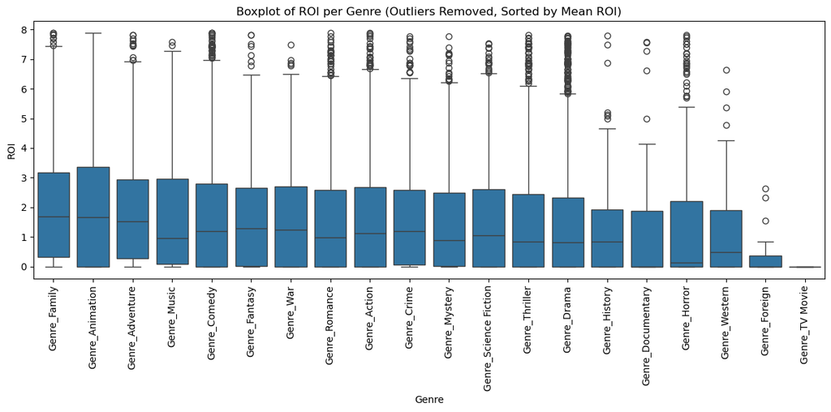

```python
# Create a list of genre columns
genre_columns = [col for col in df.columns if col.startswith('Genre_')]

# Create a DataFrame to hold ROI values and genres
roi_per_genre = []

# Collect ROI values for each genre
for genre in genre_columns:
    # Filter the DataFrame for the current genre
    genre_data = df[df[genre] == 1]

    # Append the ROI values along with the genre
    roi_per_genre.extend([(genre, roi) for roi in genre_data['ROI']])

# Convert to DataFrame
roi_per_genre_df = pd.DataFrame(roi_per_genre, columns=['Genre', 'ROI'])

# Calculate Q1, Q3, and IQR for the entire dataset
Q1 = roi_per_genre_df['ROI'].quantile(0.25)
Q3 = roi_per_genre_df['ROI'].quantile(0.75)
IQR = Q3 - Q1

# Define bounds for outliers
lower_bound = Q1 - 1.5 * IQR
upper_bound = Q3 + 1.5 * IQR

# Filter the data to remove outliers
filtered_roi_per_genre_df = roi_per_genre_df[(roi_per_genre_df['ROI'] >= lower_bound) & (roi_per_genre_df['ROI'] <= upper_bound)]

# Calculate the mean ROI for each genre and sort
mean_roi = filtered_roi_per_genre_df.groupby('Genre')['ROI'].mean().sort_values(ascending=False).reset_index()

# Create a mapping for sorted genres
genre_order = mean_roi['Genre'].tolist()

# Create the boxplot for all genres without outliers, sorted by mean ROI
plt.figure(figsize=(12, 6))
sns.boxplot(x='Genre', y='ROI', data=filtered_roi_per_genre_df, order=genre_order)
plt.xticks(rotation=90)  # Rotate genre names for better visibility
plt.title('Boxplot of ROI per Genre (Outliers Removed, Sorted by Mean ROI)')
plt.xlabel('Genre')
plt.ylabel('ROI')
plt.tight_layout()
plt.show()
```

> **Insight #6** Family and Adventure genres seems to be in top 5 considering ROI per movie according to a mean ROI with comparatively lower deviation (looking into the boxplot).

> This is consistent even if we do not perform outlier treatment or exclude only 10% of outliers, Please refer to the boxplots below.

**Boxplot, outliers removed by 10%**

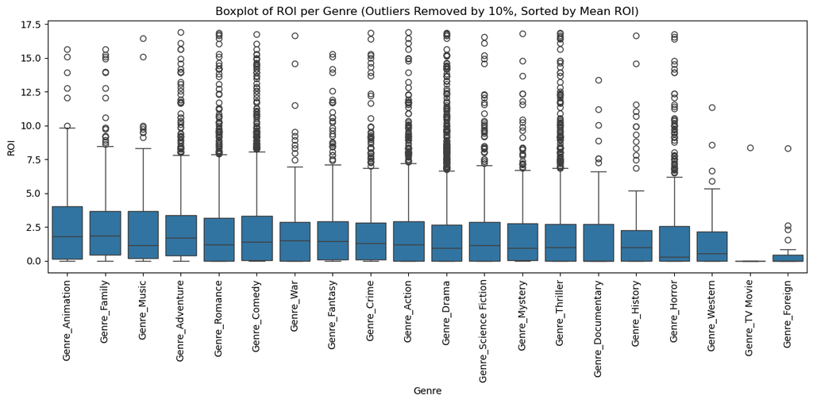

```python
# Create a list of genre columns
genre_columns = [col for col in df.columns if col.startswith('Genre_')]

# Create a DataFrame to hold ROI values and genres
roi_per_genre = []

# Collect ROI values for each genre
for genre in genre_columns:
    # Filter the DataFrame for the current genre
    genre_data = df[df[genre] == 1]

    # Append the ROI values along with the genre
    roi_per_genre.extend([(genre, roi) for roi in genre_data['ROI']])

# Convert to DataFrame
roi_per_genre_df = pd.DataFrame(roi_per_genre, columns=['Genre', 'ROI'])

# Calculate Q1, Q3, and IQR for the entire dataset
Q1 = roi_per_genre_df['ROI'].quantile(0.10)
Q3 = roi_per_genre_df['ROI'].quantile(0.90)
IQR = Q3 - Q1

# Define bounds for outliers
lower_bound = Q1 - 1.5 * IQR
upper_bound = Q3 + 1.5 * IQR

# Filter the data to remove outliers
filtered_roi_per_genre_df = roi_per_genre_df[(roi_per_genre_df['ROI'] >= lower_bound) & (roi_per_genre_df['ROI'] <= upper_bound)]

# Calculate the mean ROI for each genre and sort
mean_roi = filtered_roi_per_genre_df.groupby('Genre')['ROI'].mean().sort_values(ascending=False).reset_index()

# Create a mapping for sorted genres
genre_order = mean_roi['Genre'].tolist()

# Create the boxplot for all genres without outliers, sorted by mean ROI
plt.figure(figsize=(12, 6))
sns.boxplot(x='Genre', y='ROI', data=filtered_roi_per_genre_df, order=genre_order)
plt.xticks(rotation=90)  # Rotate genre names for better visibility
plt.title('Boxplot of ROI per Genre (Outliers Removed by 10%, Sorted by Mean ROI)')
plt.xlabel('Genre')
plt.ylabel('ROI')
plt.tight_layout()
plt.show()
```

Boxplot without Outlier treatment

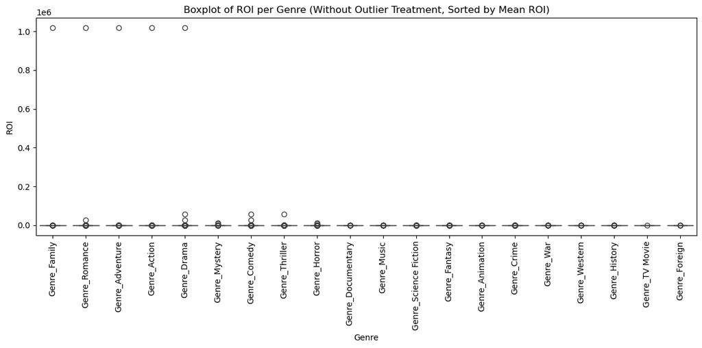

```python
# Create a list of genre columns
genre_columns = [col for col in df.columns if col.startswith('Genre_')]

# Create a DataFrame to hold ROI values and genres
roi_per_genre = []

# Collect ROI values for each genre
for genre in genre_columns:
    # Filter the DataFrame for the current genre
    genre_data = df[df[genre] == 1]

    # Append the ROI values along with the genre
    roi_per_genre.extend([(genre, roi) for roi in genre_data['ROI']])

# Convert to DataFrame
roi_per_genre_df = pd.DataFrame(roi_per_genre, columns=['Genre', 'ROI'])

# Calculate the mean ROI for each genre and sort
mean_roi = roi_per_genre_df.groupby('Genre')['ROI'].mean().sort_values(ascending=False).reset_index()

# Create a mapping for sorted genres
genre_order = mean_roi['Genre'].tolist()

# Create the boxplot for all genres without outlier treatment, sorted by mean ROI
plt.figure(figsize=(12, 6))
sns.boxplot(x='Genre', y='ROI', data=roi_per_genre_df, order=genre_order)
plt.xticks(rotation=90)
plt.title('Boxplot of ROI per Genre (Without Outlier Treatment, Sorted by Mean ROI)')
plt.xlabel('Genre')
plt.ylabel('ROI')
plt.tight_layout()
plt.show()
```

Now we will perform a similar analysis on ROI (both Total ROI and per movie), but for runtime group, release year and month

```python
# Creating a function, which calculates Total ROI per Runtime group, release year and release month.
def calculate_roi_per_category(df, category_column):
    # Create a DataFrame to hold the ROI per category
    roi_per_category = {}

    # Group by the specified category column
    grouped_data = df.groupby(category_column, observed=True)

    # Calculate ROI, average revenue, and average budget per category
    for category, group in grouped_data:
        # Calculate sums for revenue and budget for the category
        total_revenue = group['revenue_adj'].sum()
        total_budget = group['budget_adj'].sum()

        # Calculate averages for revenue and budget, we have decided to calculate in mln of USD for a better readability
        average_revenue_mln = group['revenue_adj'].mean() / 1000000
        average_budget_mln = group['budget_adj'].mean() / 1000000

        # Calculate ROI, handling division by zero
        roi = total_revenue / total_budget if total_budget > 0 else 0

        # Count the number of films in the category
        category_count = group.shape[0]

        # Store the results in a dictionary
        roi_per_category[category] = {
            'Total ROI': roi,
            'AVG Revenue, mln $': average_revenue_mln,
            'AVG Budget, mln $': average_budget_mln,
            'Category Count': category_count  # Add category count to the dictionary
        }

    # Convert the results to a DataFrame for better readability
    roi_per_category_df = pd.DataFrame.from_dict(roi_per_category, orient='index').reset_index()
    roi_per_category_df.columns = [category_column, 'Total ROI', 'AVG Revenue mln$', 'AVG Budget mln$', 'Category Count']

    # Sort the DataFrame by Total ROI in descending order
    roi_per_category_df = roi_per_category_df.sort_values(by='Total ROI', ascending=False)

    return roi_per_category_df
```

Below there is a Total ROI per runtime groups. In this report the following groups were used for runtime to increase readability and comprehension of the analysis: Short (<=90 min), Medium (> 90 min <= 111 min) and Long (>111 min) following 25, 50, 75 percentiles

```python
# Define a function to categorize runtime into groups (Short, Medium and Long)
def categorize_runtime(runtime):
    if runtime <= 90:
        return 'Short'
    elif runtime <= 111:
        return 'Medium'
    else:
        return 'Long'

# Apply the function to create a new column 'runtime_group'
df['runtime_group'] = df['runtime'].apply(categorize_runtime)
```

```python
print(calculate_roi_per_category(df, 'runtime_group'))
```

```
  runtime_group  Total ROI  AVG Revenue mln$  AVG Budget mln$  Category Count
0          Long   3.224132        112.663180        34.943721            2710
2         Short   2.666912         16.623605         6.233278            2962
1        Medium   2.626034         39.200437        14.927622            5193
```

Now let's analyze closely Runtime group in relation to ROI per movie below:

```python
def create_boxplot(df, group_by):
    # Calculate Q1, Q3, and IQR
    Q1 = df['ROI'].quantile(0.25)
    Q3 = df['ROI'].quantile(0.75)
    IQR = Q3 - Q1

    # Determine bounds for filtering outliers
    lower_bound = Q1 - 1.5 * IQR
    upper_bound = Q3 + 1.5 * IQR

    # Filter the DataFrame to remove outliers
    df_no_outliers = df[(df['ROI'] >= lower_bound) & (df['ROI'] <= upper_bound)]

    # Calculate mean ROI for each group
    mean_roi = df_no_outliers.groupby(group_by, observed = True)['ROI'].mean().reset_index()

    # Sort the group by mean ROI
    mean_roi_sorted = mean_roi.sort_values(by='ROI', ascending=False)
    sorted_groups = mean_roi_sorted[group_by].tolist()

    # Create the boxplot with sorted groups
    plt.figure(figsize=(10, 6))
    sns.boxplot(x=pd.Categorical(df_no_outliers[group_by], categories=sorted_groups, ordered=True), y='ROI', data=df_no_outliers)
    plt.title(f'Boxplot of ROI by {group_by} (Sorted by Mean ROI)')
    plt.xlabel(group_by)
    plt.ylabel('ROI')
    plt.xticks(rotation=90)
    plt.tight_layout()
    plt.show()
```

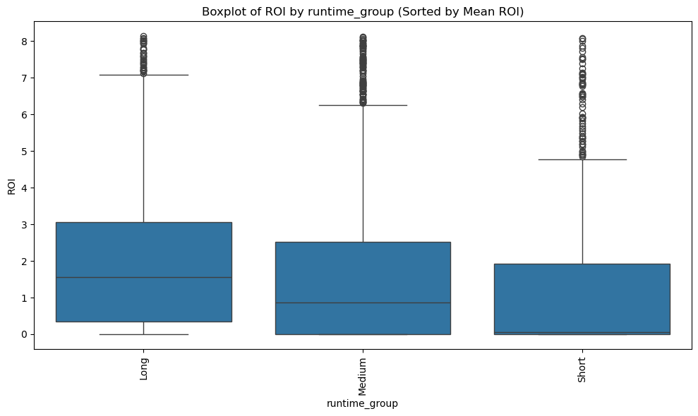

```python
create_boxplot(df, 'runtime_group')
```

> **Insight #7** According to both metrics, Long movies seem to have higher ROI both in Total ROI terms as well as a mean ROI per movie. Apparently, it makes sense to go extra mile in terms of increasing runtime and be above standard movie for duration.

Now let's analyse whether ROI was stable overtime, looking in relation to a Release year and in certain cases per release year category.

```python
print(calculate_roi_per_category(df, 'year_range'))
```

```
  year_range  Total ROI  AVG Revenue mln$  AVG Budget mln$  Category Count
4  1960-1974   6.443917         63.336191         9.828834             600
3  1975-1989   5.200672         62.968989        12.107857            1333
0  2010-2015   2.833285         38.422819        13.561227            3605
2  1990-1999   2.704997         64.297204        23.769790            1765
1  2000-2009   2.367410         51.708590        21.841837            3562
```

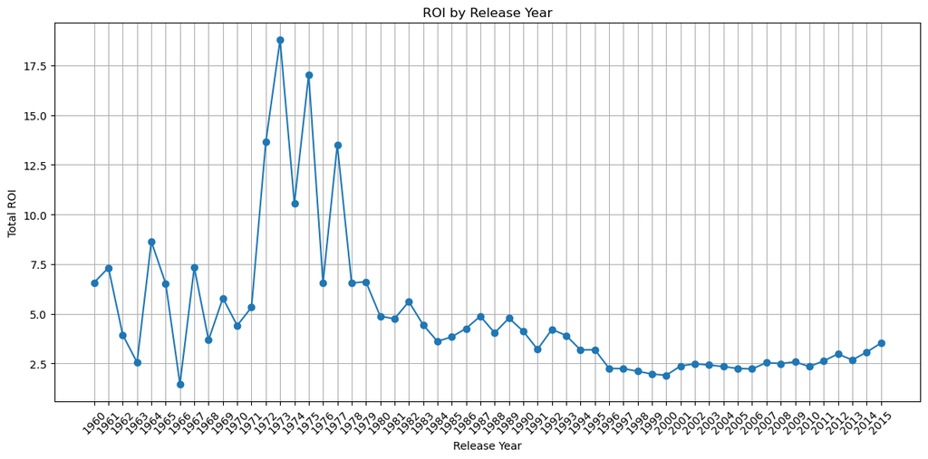

```python
# Plotting the line chart
roi_by_release_year = calculate_roi_per_category(df, 'release_year').sort_values(by='release_year')
plt.figure(figsize=(12, 6))
plt.plot(roi_by_release_year['release_year'], roi_by_release_year['Total ROI'], marker='o', linestyle='-')
plt.title('ROI by Release Year')
plt.xlabel('Release Year')
plt.ylabel('Total ROI')
plt.xticks(roi_by_release_year['release_year'], rotation=45)  # Rotate x-axis labels for better readability
plt.grid()
plt.tight_layout()
plt.show()
```

> **Insight #8** According to Total ROI line chart per year as well Total ROI calculations per year category, with an increased number of movies overtime, we see clear trend towards reduction of ROI since 1960. Apparently earlier than 1980 generally movie production industry was more profitable in terms of each US Dollar invested.

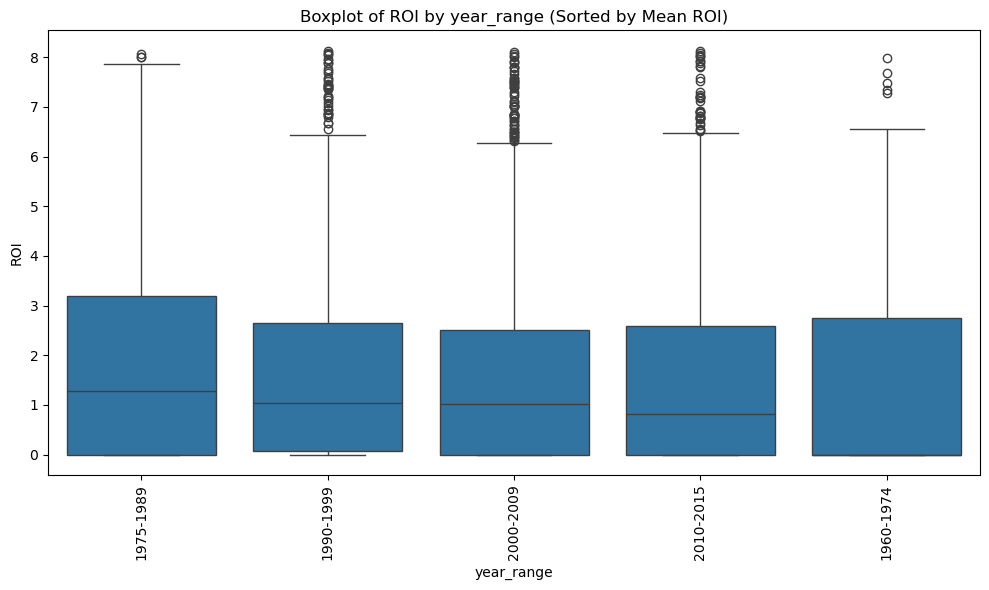

```python
create_boxplot(df, 'year_range')
```

> **Insight #9** In regards to ROI calculated per movie, we see the similar picture below: Mean ROI is going down for each year category overtime (with an exception of very early years 1960-1974), leading to the same conclusion as for the Total ROI

*When is it better to release a movie to maximize your return on investments?* We will analyse that in the section below.

```python
# Calculating Total ROI per release month
df['release_month'] = df['release_date'].dt.month

print(calculate_roi_per_category(df, 'release_month').drop('Category Count', axis=1))
```

```
    release_month  Total ROI  AVG Revenue mln$  AVG Budget mln$
5               6   3.579357         97.597610        27.266797
11             12   3.338517         84.764526        25.389877
4               5   3.306814         76.246433        23.057368
6               7   3.197194         73.292078        22.923873
10             11   3.164397         71.864960        22.710475
2               3   2.940574         49.503555        16.834656
3               4   2.573676         39.716259        15.431725
7               8   2.474918         35.468296        14.331099
9              10   2.435562         33.343614        13.690317
0               1   2.428915         18.950003         7.801837
1               2   2.179060         33.939707        15.575390
8               9   2.112519         23.259097        11.010125
```

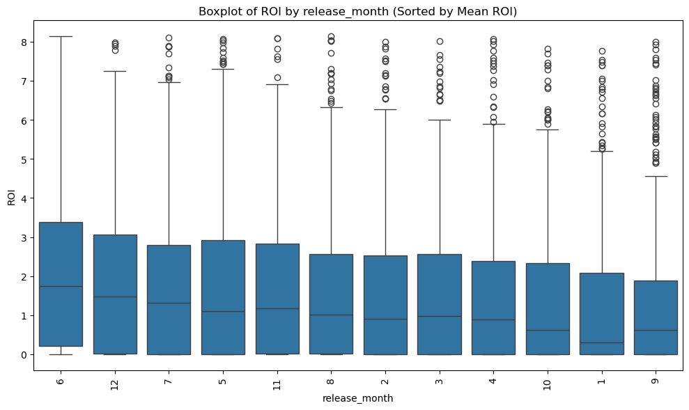

```python
create_boxplot(df, 'release_month')
```

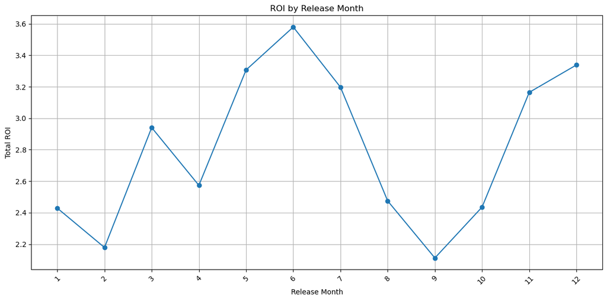

```python
# Plotting the line chart for a release month
roi_by_release_month = calculate_roi_per_category(df, 'release_month').sort_values(by='release_month')
plt.figure(figsize=(12, 6))
plt.plot(roi_by_release_month['release_month'], roi_by_release_month['Total ROI'], marker='o', linestyle='-')
plt.title('ROI by Release Month')
plt.xlabel('Release Month')
plt.ylabel('Total ROI')
plt.xticks(roi_by_release_month['release_month'], rotation=45)  # Rotate x-axis labels for better readability
plt.grid()
plt.tight_layout()
plt.show()
```

> **Insight #10** According to both ways to calculate ROI with slight differences between them, top 5 months to maximize ROI at movie level as well as for a full movie production industry are: May-June-July (around summer vacation period) and November-December (on winter holidays). September, January and February are considered to be low season months, which do not bring high ROIs to the movies released.

## Conclusions

At the start of our analysis we wanted to shed light into the below aspects:

1. What correlates with revenues the most: budgets, popularity, user rating or runtime?
2. What are the characteristics of a high ROI movie? Specifically:
> - which genres have high ROI;
> - what is the best runtime (range) of movies with the highest ROI;
> - which release months of a year have the highest ROI;
> - whether ROI changed overtime or it's rather stable in relation to a release year.

There are several limitations and data constraints:

- Data could potentially contain outliers (e.g. high values in popularity column) and incorrect data (e.g. zero budget and revenue), that can deteriorate the quality of insights derived from the analysis. An additional analysis, deep dives and cleaning can be performed, if required.
- Each movie can be in several genres, which means that the total count of all the genres is higher than the total number of movies. Subsequently, there is a duplicated statistics in those cases.
- Due to the increased number of movies (in count) overtime, the recent periods will have a bigger impact compared to earlier periods.

We hope that this Report provides you with data analysis and insights helpful in ensuring a financial success of a movie!

```python
# Running this cell will execute a bash command to convert this notebook to an .html file
!python -m nbconvert --to html Investigate_a_Dataset.ipynb
```

```
[NbConvertApp] Converting notebook Investigate_a_Dataset.ipynb to html
[NbConvertApp] WARNING | Alternative text is missing on 17 image(s).
[NbConvertApp] Writing 1966696 bytes to Investigate_a_Dataset.html
```